# MD-HT1

2024-01-25

## 1. Resumen de nuestro conjunto de datos

```r
summary(datos)
```

```
##        id             budget             genres            homePage
##  Min.   :     5   Min.   :        0   Length:10000       Length:10000
##  1st Qu.: 12286   1st Qu.:        0   Class :character   Class :character
##  Median :152558   Median :   500000   Mode  :character   Mode  :character
##  Mean   :249877   Mean   : 18551632
##  3rd Qu.:452022   3rd Qu.: 20000000
##  Max.   :922260   Max.   :380000000
##  productionCompany  productionCompanyCountry productionCountry
##  Length:10000       Length:10000             Length:10000
##  Class :character   Class :character         Class :character
##  Mode  :character   Mode  :character         Mode  :character
##
##
##
##     revenue             runtime        video           director
##  Min.   :0.000e+00   Min.   :  0.0   Mode :logical   Length:10000
##  1st Qu.:0.000e+00   1st Qu.: 90.0   FALSE:9430      Class :character
##  Median :1.631e+05   Median :100.0   TRUE :84        Mode  :character
##  Mean   :5.674e+07   Mean   :100.3   NA's :486
##  3rd Qu.:4.480e+07   3rd Qu.:113.0
##  Max.   :2.847e+09   Max.   :750.0
##     actors          actorsPopularity   actorsCharacter    originalTitle
##  Length:10000       Length:10000       Length:10000       Length:10000
##  Class :character   Class :character   Class :character   Class :character
##  Mode  :character   Mode  :character   Mode  :character   Mode  :character
##
##
##
##     title           originalLanguage     popularity        releaseDate
##  Length:10000       Length:10000       Min.   :    4.258   Length:10000
##  Class :character   Class :character   1st Qu.:   14.578   Class :character
##  Mode  :character   Mode  :character   Median :   21.906   Mode  :character
##                                        Mean   :   51.394
##                                        3rd Qu.:   40.654
##                                        Max.   :11474.647
##     voteAvg         voteCount      genresAmount    productionCoAmount
##  Min.   : 1.300   Min.   :    1   Min.   : 0.000   Min.   : 0.000
##  1st Qu.: 5.900   1st Qu.:  120   1st Qu.: 2.000   1st Qu.: 2.000
##  Median : 6.500   Median :  415   Median : 3.000   Median : 3.000
##  Mean   : 6.483   Mean   : 1342   Mean   : 2.596   Mean   : 3.171
##  3rd Qu.: 7.200   3rd Qu.: 1316   3rd Qu.: 3.000   3rd Qu.: 4.000
##  Max.   :10.000   Max.   :30788   Max.   :16.000   Max.   :89.000
##  productionCountriesAmount  actorsAmount    castWomenAmount
##  Min.   :  0.000           Min.   :     0   Length:10000
##  1st Qu.:  1.000           1st Qu.:    13   Class :character
##  Median :  1.000           Median :    21   Mode  :character
##  Mean   :  1.751           Mean   :  2148
##  3rd Qu.:  2.000           3rd Qu.:    36
##  Max.   :155.000           Max.   :919590
##  castMenAmount
##  Length:10000
##  Class :character
##  Mode  :character
##
##
##
```

## 2. Diga el tipo de cada una de las variables (cualitativa ordinal o nominal, cuantitativa continua, cuantitativa discreta)

```r
if (!requireNamespace("knitr", quietly = TRUE)) {
  install.packages("knitr")
}

library(knitr)
# Definir manualmente los tipos de variables que son cada una
tipo <- c("Cuantitativa discreta", "Cuantitativa continua", "Cualitativa nominal",
                    "Cualitativa nominal", "Cualitativa nominal", "Cualitativa nominal",
                    "Cualitativa nominal", "Cuantitativa continua",
                    "Cuantitativa continua", "Cualitativa nominal", "Cualitativa nominal",
                    "Cualitativa nominal", "Cuantitativa continua", "Cualitativa nominal",
                    "Cualitativa nominal", "Cualitativa nominal", "Cualitativa nominal",
                    "Cuantitativa continua", "Cualitativa nominal", "Cuantitativa continua",
                    "Cuantitativa discreta", "Cuantitativa discreta", "Cuantitativa discreta",
                    "Cuantitativa discreta", "Cuantitativa discreta", "Cuantitativa discreta",
                    "Cuantitativa discreta")

# Crear un dataframe con los nombres de las columnas y los tipos que son
tabla_columnas_valores <- data.frame(Variables = colnames(datos), TipoVariable = tipo)

# Imprimir la tabla usando kable()
kable(tabla_columnas_valores, format = "html", row.names = TRUE)
```

|  | Variables | TipoVariable |
| --- | --- | --- |
| 1 | id | Cuantitativa discreta |
| 2 | budget | Cuantitativa continua |
| 3 | genres | Cualitativa nominal |
| 4 | homePage | Cualitativa nominal |
| 5 | productionCompany | Cualitativa nominal |
| 6 | productionCompanyCountry | Cualitativa nominal |
| 7 | productionCountry | Cualitativa nominal |
| 8 | revenue | Cuantitativa continua |
| 9 | runtime | Cuantitativa continua |
| 10 | video | Cualitativa nominal |
| 11 | director | Cualitativa nominal |
| 12 | actors | Cualitativa nominal |
| 13 | actorsPopularity | Cuantitativa continua |
| 14 | actorsCharacter | Cualitativa nominal |
| 15 | originalTitle | Cualitativa nominal |
| 16 | title | Cualitativa nominal |
| 17 | originalLanguage | Cualitativa nominal |
| 18 | popularity | Cuantitativa continua |
| 19 | releaseDate | Cualitativa nominal |
| 20 | voteAvg | Cuantitativa continua |
| 21 | voteCount | Cuantitativa discreta |
| 22 | genresAmount | Cuantitativa discreta |
| 23 | productionCoAmount | Cuantitativa discreta |
| 24 | productionCountriesAmount | Cuantitativa discreta |
| 25 | actorsAmount | Cuantitativa discreta |
| 26 | castWomenAmount | Cuantitativa discreta |
| 27 | castMenAmount | Cuantitativa discreta |

## 3. Investigue si las variables cuantitativas siguen una distribución normal y haga una tabla de frecuencias de las variables cualitativas. Explique todos los resultados.

### budget

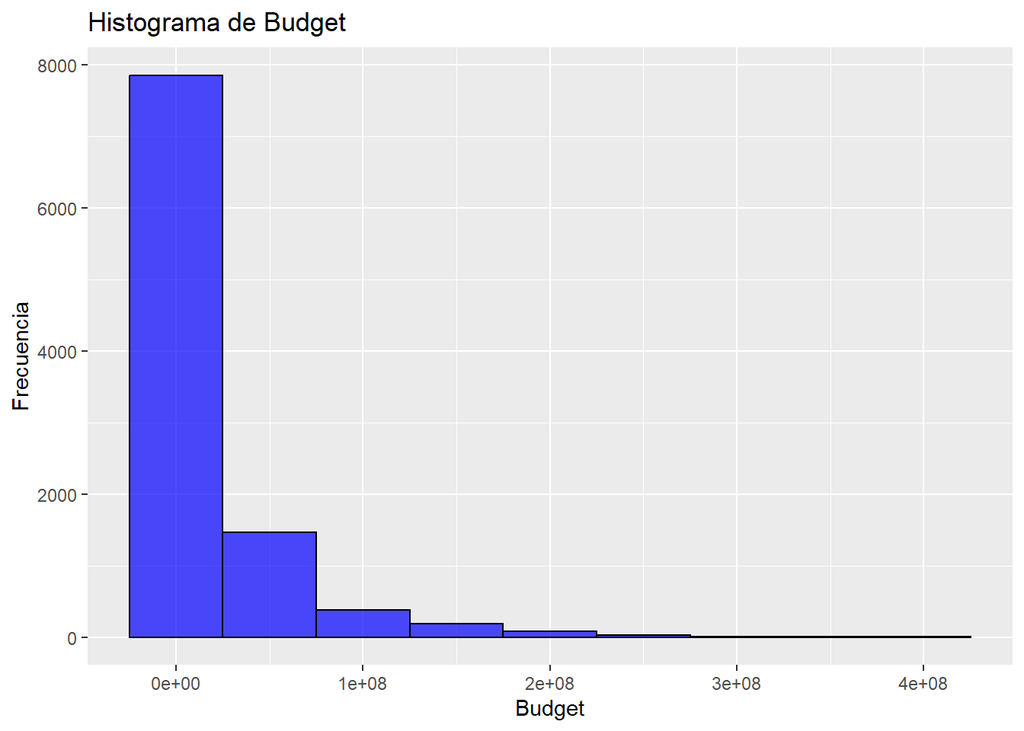

```r
# Descargamos ggplot2
if (!requireNamespace("ggplot2", quietly = TRUE)) {
  install.packages("ggplot2")
}
library(ggplot2)

# Tomemos 'budget' como ejemplo
budget_data <- datos$budget

# Crear histograma
hist_plot <- ggplot(data.frame(x = budget_data), aes(x = x)) +
  geom_histogram(binwidth = 50000000, fill = "blue", color = "black", alpha = 0.7) +
  labs(title = "Histograma de Budget",
       x = "Budget",
       y = "Frecuencia")

# Crear QQ-Plot
qq_plot <- ggplot(data.frame(x = budget_data), aes(sample = x)) +
  geom_qq() +
  geom_qq_line(color = "blue") +
  labs(title = "QQ-Plot de Budget",
       x = "Cuantiles teóricos",
       y = "Cuantiles observados")

# Imprimir los gráficos
print(hist_plot)
```

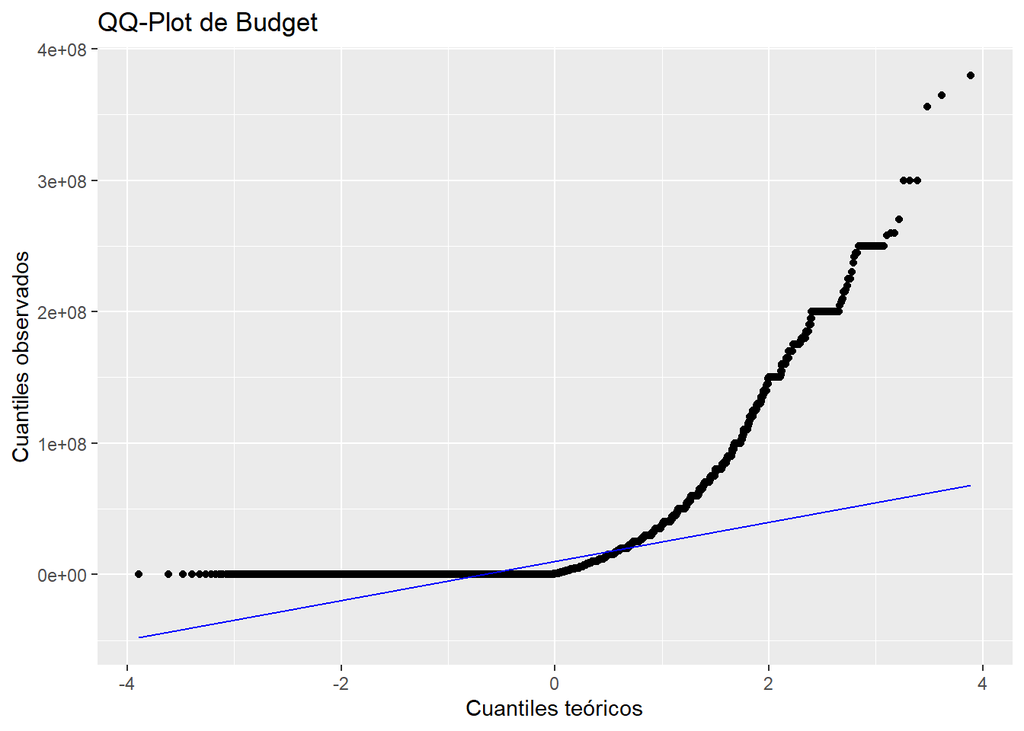

```r
print(qq_plot)
```

### revenue

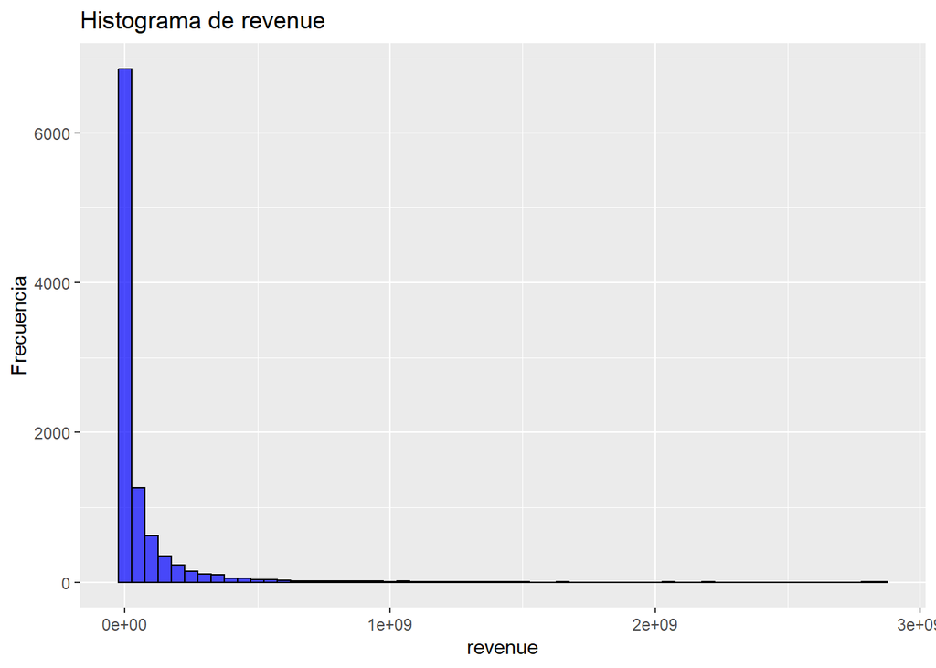

```r
library(ggplot2)

# Tomemos 'revenue' como ejemplo
revenue_data <- datos$revenue

# Crear histograma
hist_plot <- ggplot(data.frame(x = revenue_data), aes(x = x)) +
  geom_histogram(binwidth = 50000000, fill = "blue", color = "black", alpha = 0.7) +
  labs(title = "Histograma de revenue",
       x = "revenue",
       y = "Frecuencia")

# Crear QQ-Plot
qq_plot <- ggplot(data.frame(x = revenue_data), aes(sample = x)) +
  geom_qq() +
  geom_qq_line(color = "blue") +
  labs(title = "QQ-Plot de revenue",
       x = "Cuantiles teóricos",
       y = "Cuantiles observados")

# Imprimir los gráficos
print(hist_plot)
```

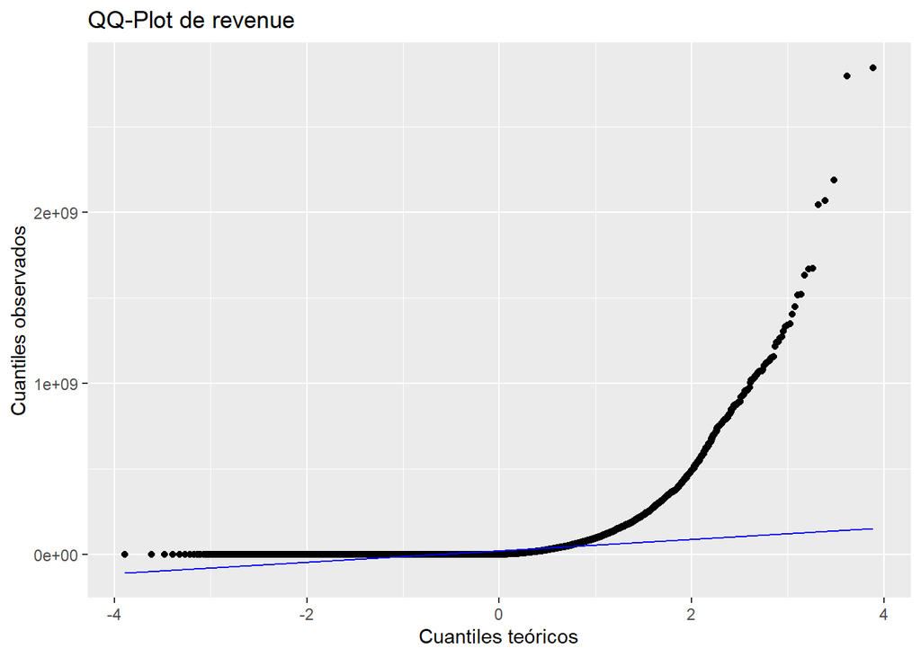

```r
print(qq_plot)
```

### runtime

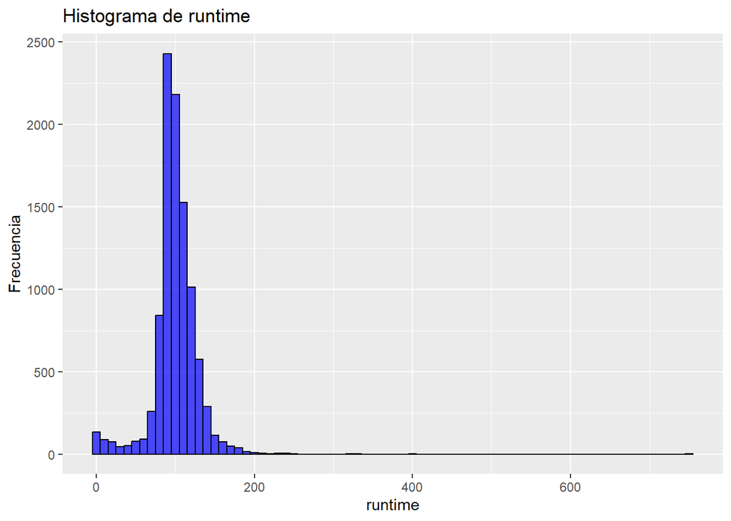

```r
library(ggplot2)

# Tomemos 'runtime' como ejemplo
runtime_data <- datos$runtime

# Crear histograma
hist_plot <- ggplot(data.frame(x = runtime_data), aes(x = x)) +
  geom_histogram(binwidth = 10, fill = "blue", color = "black", alpha = 0.7) +
  labs(title = "Histograma de runtime",
       x = "runtime",
       y = "Frecuencia")

# Crear QQ-Plot
qq_plot <- ggplot(data.frame(x = runtime_data), aes(sample = x)) +
  geom_qq() +
  geom_qq_line(color = "blue") +
  labs(title = "QQ-Plot de runtime",
       x = "Cuantiles teóricos",
       y = "Cuantiles observados")

# Imprimir los gráficos
print(hist_plot)
```

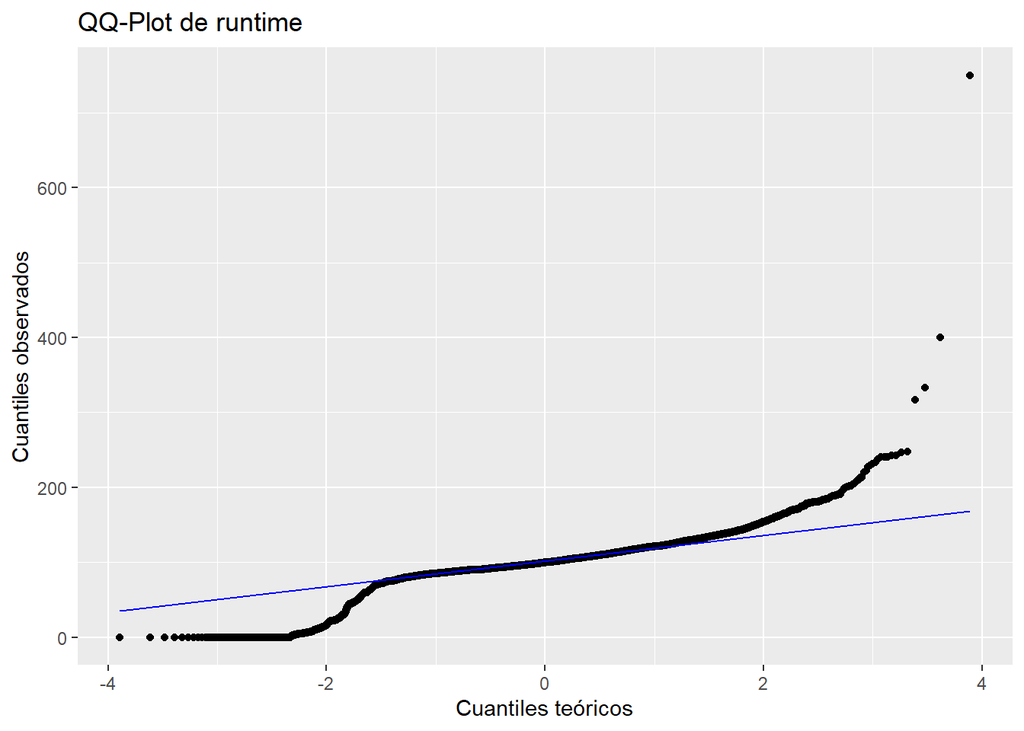

```r
print(qq_plot)
```

### actorsPopularity

Debido a como vienen los valores es imposible generar un hisograma y un grfico qq por lo que este no se muestra

### popularity

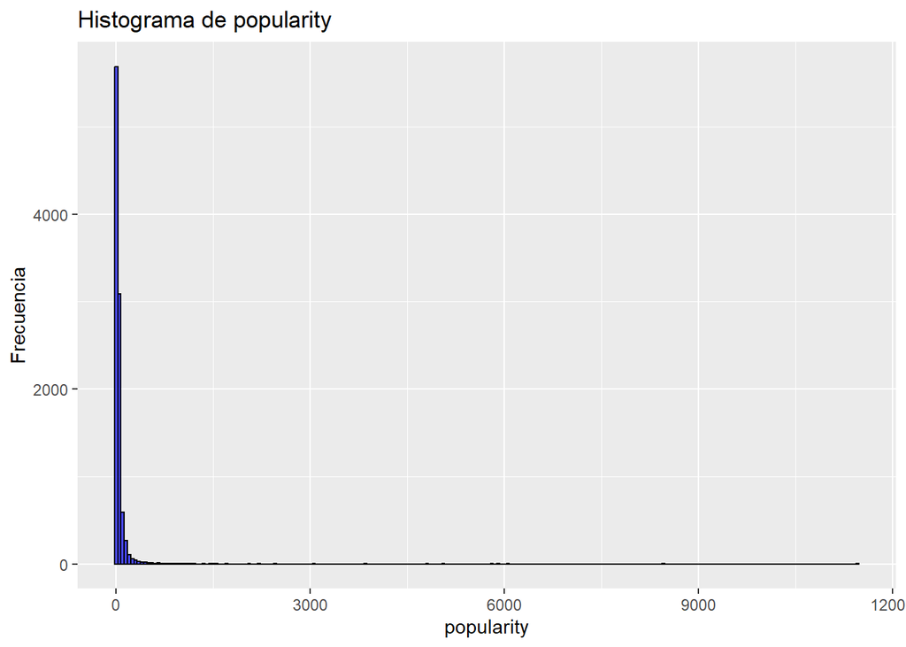

```r
library(ggplot2)

# Tomemos 'popularity' como ejemplo
popularity_data <- datos$popularity

# Crear histograma
hist_plot <- ggplot(data.frame(x = popularity_data), aes(x = x)) +
  geom_histogram(binwidth = 50, fill = "blue", color = "black", alpha = 0.7) +
  labs(title = "Histograma de popularity",
       x = "popularity",
       y = "Frecuencia")

# Crear QQ-Plot
qq_plot <- ggplot(data.frame(x = popularity_data), aes(sample = x)) +
  geom_qq() +
  geom_qq_line(color = "blue") +
  labs(title = "QQ-Plot de popularity",
       x = "Cuantiles teóricos",
       y = "Cuantiles observados")

# Imprimir los gráficos
print(hist_plot)
```

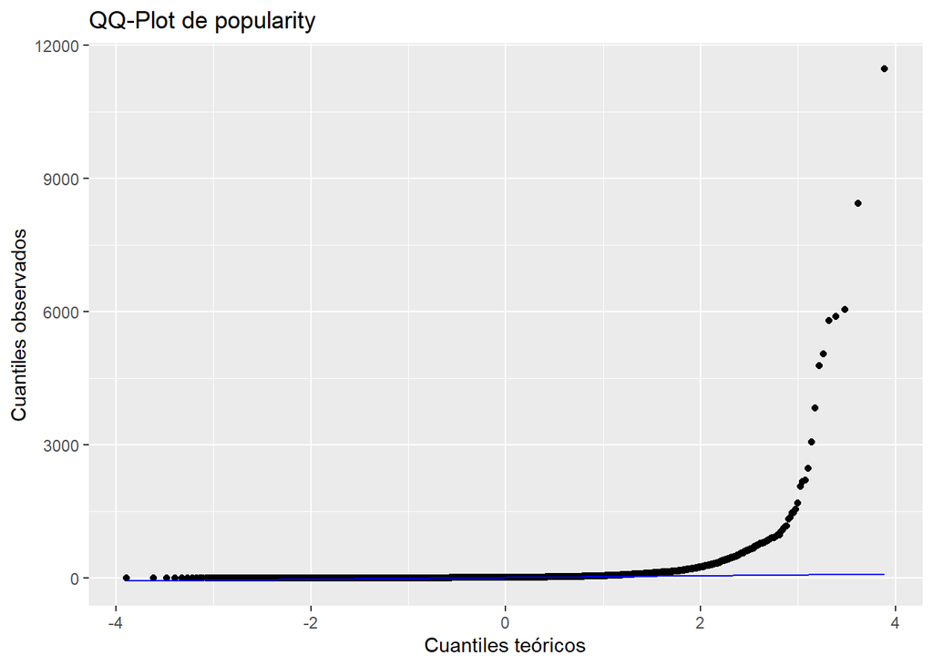

```r
print(qq_plot)
```

### voteAvg

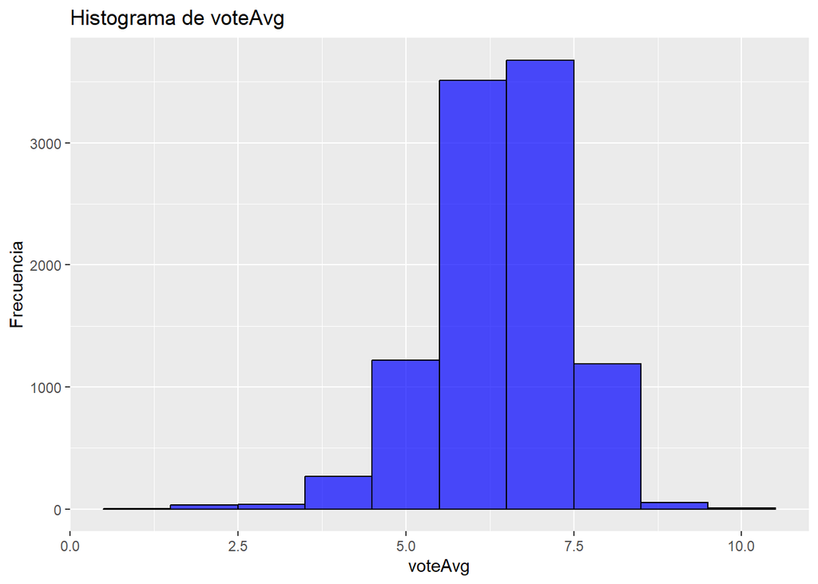

```r
library(ggplot2)

# Tomemos 'voteAvg' como ejemplo
voteAvg_data <- datos$voteAvg

# Crear histograma
hist_plot <- ggplot(data.frame(x = voteAvg_data), aes(x = x)) +
  geom_histogram(binwidth = 1, fill = "blue", color = "black", alpha = 0.7) +
  labs(title = "Histograma de voteAvg",
       x = "voteAvg",
       y = "Frecuencia")

# Crear QQ-Plot
qq_plot <- ggplot(data.frame(x = voteAvg_data), aes(sample = x)) +
  geom_qq() +
  geom_qq_line(color = "blue") +
  labs(title = "QQ-Plot de voteAvg",
       x = "Cuantiles teóricos",
       y = "Cuantiles observados")

# Imprimir los gráficos
print(hist_plot)
```

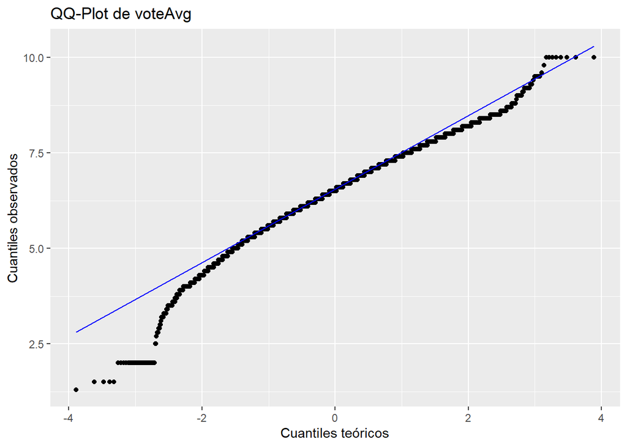

```r
print(qq_plot)
```

### voteCount

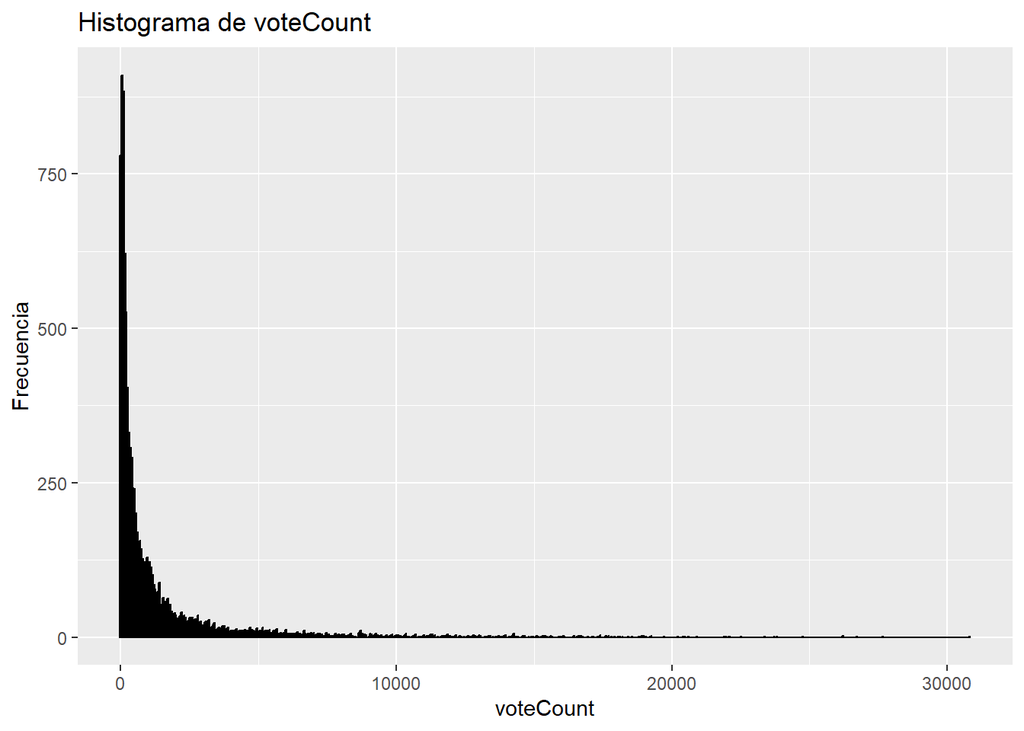

```r
library(ggplot2)

# Tomemos 'voteCount' como ejemplo
voteCount_data <- datos$voteCount

# Crear histograma
hist_plot <- ggplot(data.frame(x = voteCount_data), aes(x = x)) +
  geom_histogram(binwidth = 50, fill = "blue", color = "black", alpha = 0.7) +
  labs(title = "Histograma de voteCount",
       x = "voteCount",
       y = "Frecuencia")

# Crear QQ-Plot
qq_plot <- ggplot(data.frame(x = voteCount_data), aes(sample = x)) +
  geom_qq() +
  geom_qq_line(color = "blue") +
  labs(title = "QQ-Plot de voteCount",
       x = "Cuantiles teóricos",
       y = "Cuantiles observados")

# Imprimir los gráficos
print(hist_plot)
```

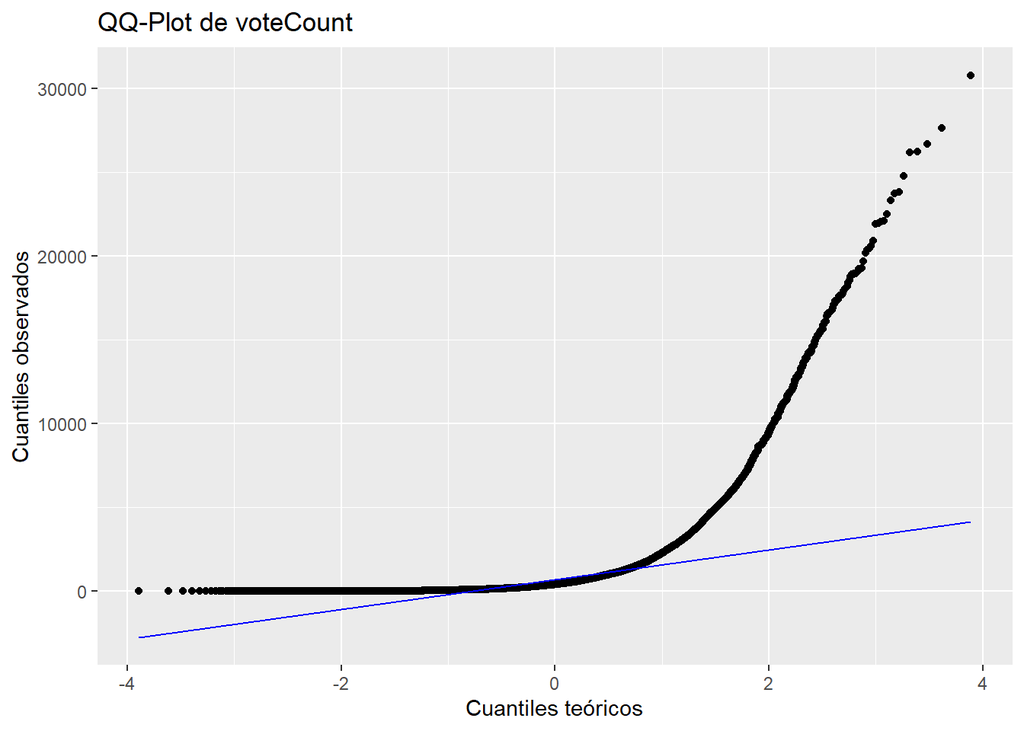

```r
print(qq_plot)
```

### genresAmount

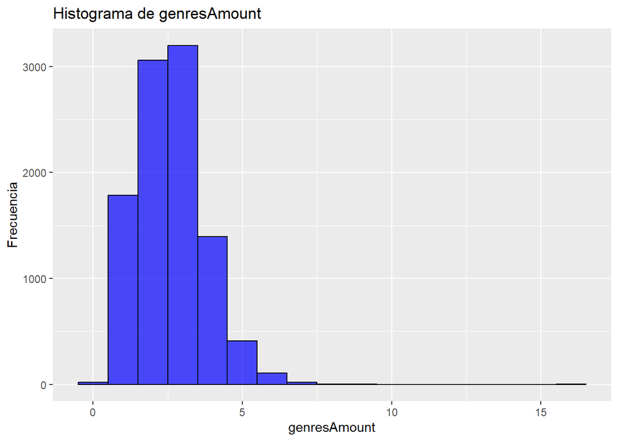

```r
library(ggplot2)

# Tomemos 'genresAmount' como ejemplo
genresAmount_data <- datos$genresAmount

# Crear histograma
hist_plot <- ggplot(data.frame(x = genresAmount_data), aes(x = x)) +
  geom_histogram(binwidth = 1, fill = "blue", color = "black", alpha = 0.7) +
  labs(title = "Histograma de genresAmount",
       x = "genresAmount",
       y = "Frecuencia")

# Crear QQ-Plot
qq_plot <- ggplot(data.frame(x = genresAmount_data), aes(sample = x)) +
  geom_qq() +
  geom_qq_line(color = "blue") +
  labs(title = "QQ-Plot de genresAmount",
       x = "Cuantiles teóricos",
       y = "Cuantiles observados")

# Imprimir los gráficos
print(hist_plot)
```

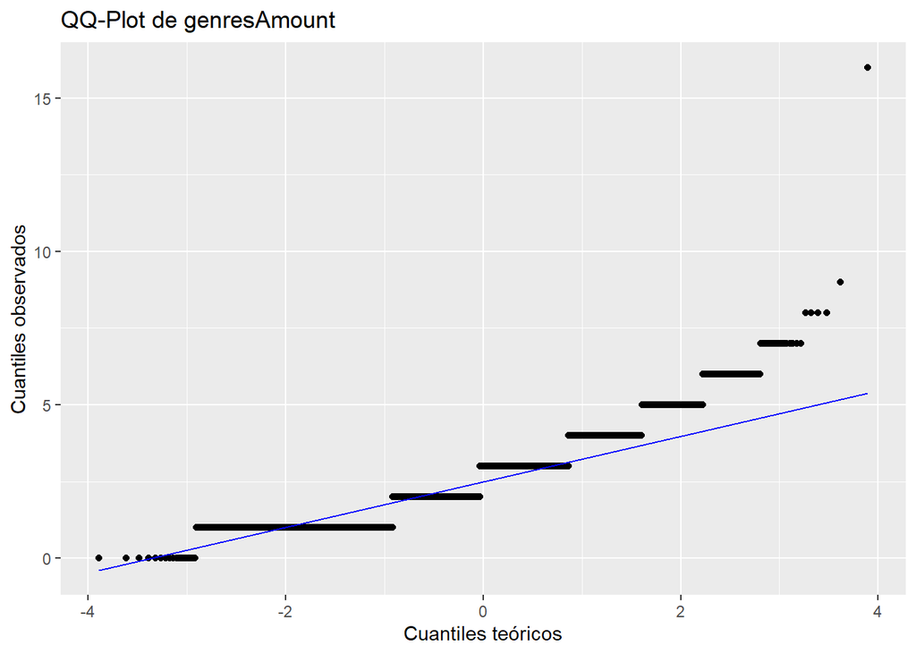

```r
print(qq_plot)
```

### productionCoAmount

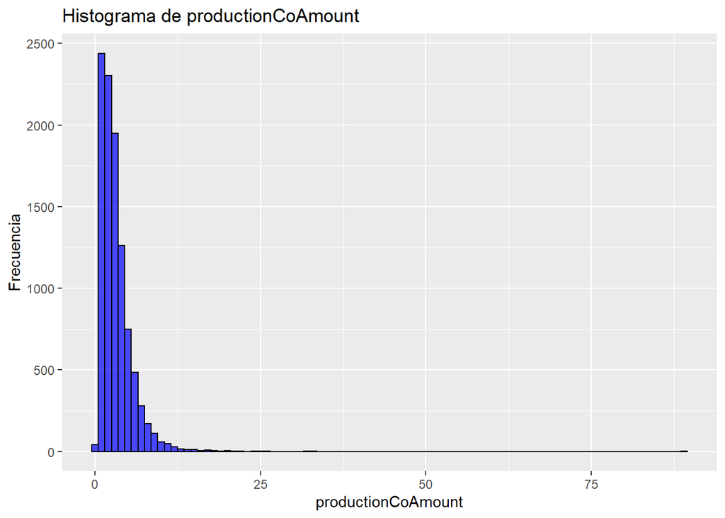

```r
library(ggplot2)

# Tomemos 'productionCoAmount' como ejemplo
productionCoAmount_data <- datos$productionCoAmount

# Crear histograma
hist_plot <- ggplot(data.frame(x = productionCoAmount_data), aes(x = x)) +
  geom_histogram(binwidth = 1, fill = "blue", color = "black", alpha = 0.7) +
  labs(title = "Histograma de productionCoAmount",
       x = "productionCoAmount",
       y = "Frecuencia")

# Crear QQ-Plot
qq_plot <- ggplot(data.frame(x = productionCoAmount_data), aes(sample = x)) +
  geom_qq() +
  geom_qq_line(color = "blue") +
  labs(title = "QQ-Plot de productionCoAmount",
       x = "Cuantiles teóricos",
       y = "Cuantiles observados")

# Imprimir los gráficos
print(hist_plot)
```

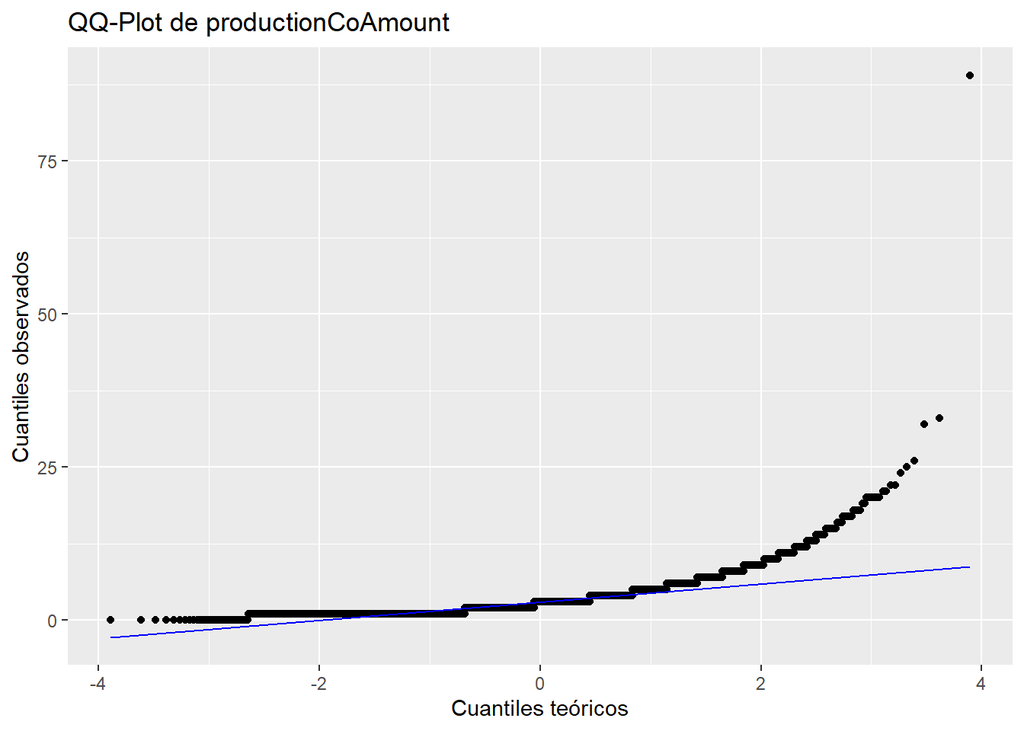

```r
print(qq_plot)
```

### productionCountriesAmount

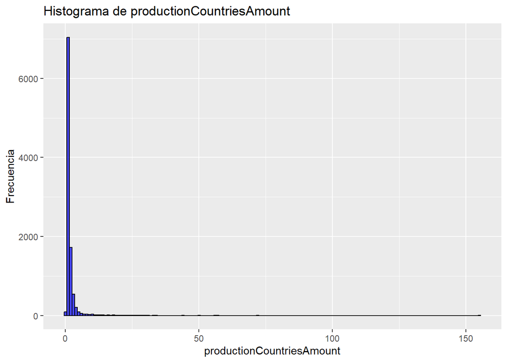

```r
library(ggplot2)

productionCountriesAmount_data <- datos$productionCountriesAmount

# Crear histograma
hist_plot <- ggplot(data.frame(x = productionCountriesAmount_data), aes(x = x)) +
  geom_histogram(binwidth = 1, fill = "blue", color = "black", alpha = 0.7) +
  labs(title = "Histograma de productionCountriesAmount",
       x = "productionCountriesAmount",
       y = "Frecuencia")

# Crear QQ-Plot
qq_plot <- ggplot(data.frame(x = productionCountriesAmount_data), aes(sample = x)) +
  geom_qq() +
  geom_qq_line(color = "blue") +
  labs(title = "QQ-Plot de productionCountriesAmount",
       x = "Cuantiles teóricos",
       y = "Cuantiles observados")

# Imprimir los gráficos
print(hist_plot)
```

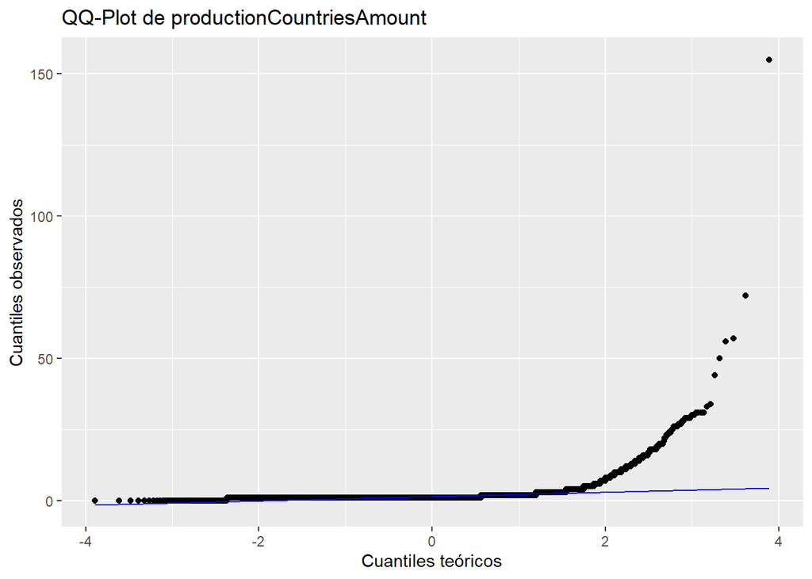

```r
print(qq_plot)
```

### actorsAmount

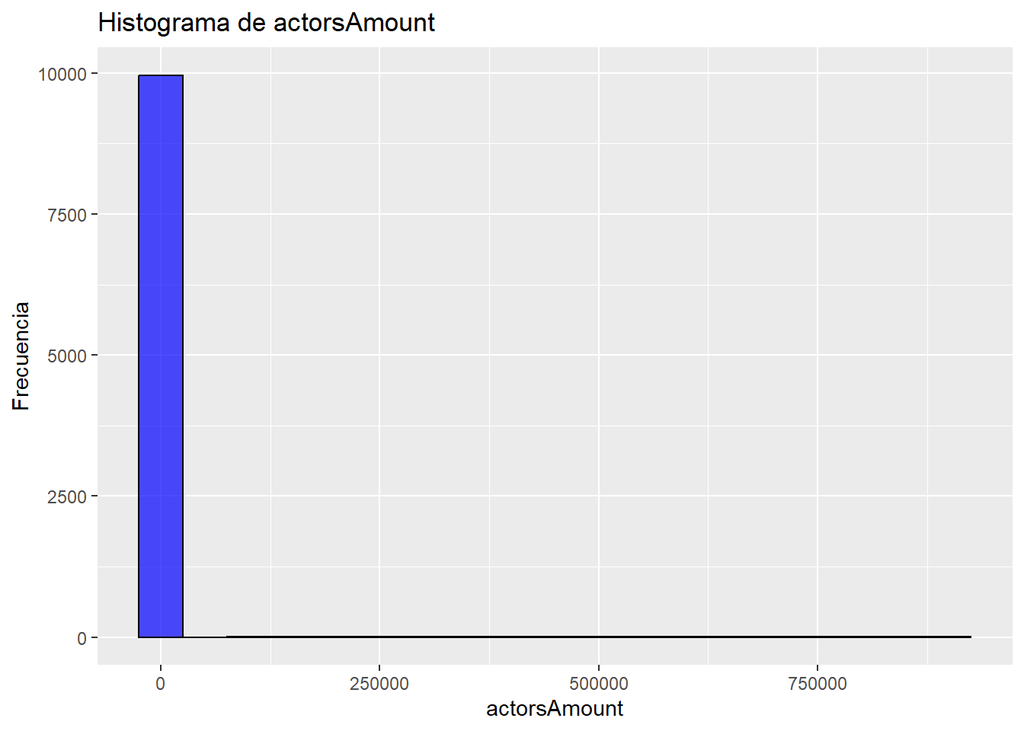

```r
library(ggplot2)

actorsAmount_data <- datos$actorsAmount

# Crear histograma
hist_plot <- ggplot(data.frame(x = actorsAmount_data ), aes(x = x)) +
  geom_histogram(binwidth = 50000, fill = "blue", color = "black", alpha = 0.7) +
  labs(title = "Histograma de actorsAmount",
       x = "actorsAmount",
       y = "Frecuencia")

# Crear QQ-Plot
qq_plot <- ggplot(data.frame(x = actorsAmount_data ), aes(sample = x)) +
  geom_qq() +
  geom_qq_line(color = "blue") +
  labs(title = "QQ-Plot de actorsAmount",
       x = "Cuantiles teóricos",
       y = "Cuantiles observados")

# Imprimir los gráficos
print(hist_plot)
```

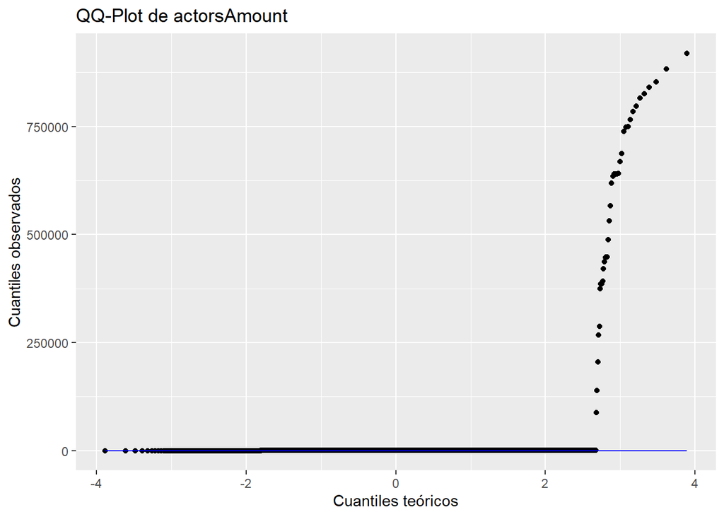

```r
print(qq_plot)
```

### castWomenAmount

Debido a como vienen los valores en formato string es imposible generar un hisograma y un gráfico qq por lo que este no se muestra

### castMenAmount

Debido a como vienen los valores en formato string es imposible generar un hisograma y un gráfico qq por lo que este no se muestra

## Parrafo de variables cuantitativas

Respecto a los histogramas de las variables cuantitativas, se observa que muy pocas de ellas sigue una distribución normal y algunos de ellos no son posibles utilizarlos ya que son string

La variable runtime posee una curtosis leptocúrtica, pero las variables voteaverage y genresAmount tienen una curtosis mesocúrtica.

### Genres

```r
# Crear tabla de frecuencias para la variable "genres"
genres_sep <- strsplit(as.character(datos$genres), "\\|")
genres_sep <- data.frame(genres = unlist(genres_sep))
genres_table <- as.data.frame(table(genres_sep))
colnames(genres_table) <- c("Valor", "Frecuencia")
# Suprimir advertencias solo para la conversión
suppressWarnings({
  # Convertir las cadenas antes de imprimir
  genres_table$Valor <- iconv(genres_table$Valor, to = "UTF-8", sub = "byte")
  # Imprimir solo las primeras filas de la tabla
  print(head(genres_table))
})
```

```
##         Valor Frecuencia
## 1      Action       2632
## 2   Adventure       1769
## 3   Animation       1460
## 4      Comedy       3018
## 5       Crime       1225
## 6 Documentary        299
```

### productionCompany

```
##                              Valor Frecuencia
## 1  "DIA" Productions GmbH & Co. KG          1
## 8                  01 Distribution          9
## 9                 1-2-3 Production          1
## 10                 10 West Studios          1
## 11                     10.80 Films          1
## 12                       100 Bares          1
```

### productionCompanyCountry

```
##       Valor Frecuencia
## 1                 5991
## 2        AE         22
## 3        AR         92
## 4 Argentina          1
## 5        AT         23
## 6        AU        189
```

### productionCountry

```
##         Valor Frecuencia
## 1 Afghanistan          1
## 2     Albania          2
## 3     Algeria          1
## 4      Angola          1
## 5  Antarctica          1
## 6   Argentina         70
```

### video

```
##   Valor Frecuencia
## 1 FALSE       9430
## 2  TRUE         84
```

### director

```
##                                                                       Valor
## 1 야마모토 야스이치로
## 2                                                                A.B. Stone
## 3                                                              A.C. Bradley
## 4                                                           A.R. Murugadoss
## 5                                                                Aamir Khan
## 6                                                              Aaron Blaise
##   Frecuencia
## 1          1
## 2          1
## 3          1
## 4          1
## 5          1
## 6          1
```

### actors

```
##                 Valor Frecuencia
## 1   'El Indio' Rincon          1
## 2      'Snub' Pollard          3
## 3 'Weird Al' Yankovic          6
## 4  'Wild Bill' Laczko          2
## 5     Amanda Phillips          1
## 6      "Kobra" Devoux          1
```

### actorsCharacter

```
##                             Valor Frecuencia
## 1                                       3107
## 2 ''You Will Be Found'' Performer         16
## 3                    '1+1' Dancer          1
## 4                   '40s Prisoner          1
## 5                   '50s Gangster          1
## 6                      '60s Model          3
```

### originalTitle

```
##                                Valor Frecuencia
## 1                                '71          1
## 2  #살아있다          1
## 3       #AnneFrank. Parallel Stories          1
## 4                       #realityhigh          1
## 5               (500) Days of Summer          1
## 6 (T)Raumschiff Surprise - Periode 1          1
```

### title

```
##                                Valor Frecuencia
## 1                                '71          1
## 2                             #Alive          1
## 3       #AnneFrank. Parallel Stories          1
## 4                       #realityhigh          1
## 5               (500) Days of Summer          1
## 6 (T)Raumschiff Surprise - Periode 1          1
```

### originalLanguage

```
##   Valor Frecuencia
## 1    ar          1
## 2    bn          1
## 3    ca          1
## 4    cn         80
## 5    cs          2
## 6    da         27
```

### releaseDate

```
##        Valor Frecuencia
## 1 1902-04-17          1
## 2 1920-02-27          1
## 3 1921-01-21          1
## 4 1922-02-17          1
## 5 1925-07-12          1
## 6 1925-12-24          1
```

## Parrafo de variables cualitativas

En estas variables evidenciamos que poseemos variables las cuales al poseer la mayoria frecuencias de 1 no vale mucho la pena poseerlas, a pesar de ello se graficáron pero no eran relevantes ya que, como en las fechas, estas normalmente cada una de ellas tiene una frecuencia muy baja

## 4.Responda las siguientes preguntas:

### 4.1 ¿Cuáles son las 10 películas que contaron con más presupuesto?

```r
# Instalar y cargar el paquete dplyr si aún no está instalado
if (!requireNamespace("dplyr", quietly = TRUE)) {
  install.packages("dplyr")
}

library(dplyr)

# Seleccionar las primeras 10 filas
top_10_presupuesto <- head(dplyr::arrange(datos, desc(budget)), 10)

# Imprimir el resultado
print(top_10_presupuesto[, c("title", "budget")])
```

```
##                                          title    budget
## 1  Pirates of the Caribbean: On Stranger Tides 380000000
## 2                      Avengers: Age of Ultron 365000000
## 3                            Avengers: Endgame 356000000
## 4     Pirates of the Caribbean: At World's End 300000000
## 5                               Justice League 300000000
## 6                       Avengers: Infinity War 300000000
## 7                             Superman Returns 270000000
## 8                                      Tangled 260000000
## 9                                The Lion King 260000000
## 10                                Spider-Man 3 258000000
```

```r
for (i in 1:10) {
  cat("Película:", top_10_presupuesto$title[i], "\t Budget:", top_10_presupuesto$budget[i], "\n")
}
```

```
## Película: Pirates of the Caribbean: On Stranger Tides     Budget: 380000000
## Película: Avengers: Age of Ultron     Budget: 365000000
## Película: Avengers: Endgame   Budget: 356000000
## Película: Pirates of the Caribbean: At World's End    Budget: 300000000
## Película: Justice League      Budget: 300000000
## Película: Avengers: Infinity War      Budget: 300000000
## Película: Superman Returns    Budget: 270000000
## Película: Tangled     Budget: 260000000
## Película: The Lion King   Budget: 260000000
## Película: Spider-Man 3    Budget: 258000000
```

### 4.2 ¿Cuáles son las 10 películas que más ingresos tuvieron?

```r
# Seleccionar las primeras 10 filas
top_10_ingresos <- head(datos[order(-datos$revenue), ], 10)

# Imprimir el resultado
print(top_10_ingresos[, c("title", "revenue")])
```

```
##                             title    revenue
## 3211                       Avatar 2847246203
## 5953            Avengers: Endgame 2797800564
## 308                       Titanic 2187463944
## 4948 Star Wars: The Force Awakens 2068223624
## 5954       Avengers: Infinity War 2046239637
## 4915               Jurassic World 1671713208
## 7135                The Lion King 1667635327
## 9050      Spider-Man: No Way Home 1631853496
## 3398                 The Avengers 1518815515
## 5088                    Furious 7 1515047671
```

```r
cat("\nTop 10 Películas con Mayor Ingreso:\n")
```

```
##
## Top 10 Películas con Mayor Ingreso:
```

```r
for (i in 1:10) {
  cat("Película:", top_10_ingresos$title[i], "\tIngreso:", top_10_ingresos$revenue[i], "\n")
}
```

```
## Película: Avatar     Ingreso: 2847246203
## Película: Avengers: Endgame  Ingreso: 2797800564
## Película: Titanic    Ingreso: 2187463944
## Película: Star Wars: The Force Awakens   Ingreso: 2068223624
## Película: Avengers: Infinity War     Ingreso: 2046239637
## Película: Jurassic World     Ingreso: 1671713208
## Película: The Lion King  Ingreso: 1667635327
## Película: Spider-Man: No Way Home    Ingreso: 1631853496
## Película: The Avengers   Ingreso: 1518815515
## Película: Furious 7  Ingreso: 1515047671
```

### 4.3 ¿Cuál es la película que más votos tuvo?

```r
# Seleccionar las primeras 10 filas
top_voteCount <- head(datos[order(-datos$voteCount), ], 1)

# Imprimir el resultado
print(top_voteCount[, c("title", "voteCount")])
```

```
##          title voteCount
## 3512 Inception     30788
```

### 4.4 ¿Cuál es la peor película de acuerdo a los votos de todos los usuarios?

```r
# Seleccionar la película con la peor calificación (voto promedio)
worst_voteAvg <- datos[which.min(datos$voteAvg), c("title", "voteAvg")]

# Imprimir el resultado
cat("La película con la peor calificación es:", worst_voteAvg$title, "con un voto promedio de:", worst_voteAvg$voteAvg, "\n")
```

```
## La película con la peor calificación es: DAKAICHI -I'm Being Harassed by the Sexiest Man of the Year- The Movie: In Spain con un voto promedio de: 1.3
```

### 4.5 ¿Cuántas películas se hicieron en cada año? ¿En qué año se hicieron más películas? Haga un gráfico de barras

```r
# Suponiendo que releaseDate es una cadena en el formato "YYYY-MM-DD"
datos$releaseYear <- as.numeric(format(as.Date(datos$releaseDate), "%Y"))

# Crear tabla con el número de películas por año
peliculas_por_ano <- table(datos$releaseYear)

# Encontrar el año con más películas
ano_mas_peliculas <- names(peliculas_por_ano[which.max(peliculas_por_ano)])

# Imprimir el número de películas por año
cat("Número de películas por año:\n")
```

```
## Número de películas por año:
```

```r
print(peliculas_por_ano)
```

```
##
## 1902 1920 1921 1922 1925 1926 1927 1929 1930 1931 1932 1933 1935 1936 1937 1938
##    1    1    1    1    2    1    2    1    1    4    1    1    1    1    1    1
## 1939 1940 1941 1942 1943 1944 1946 1947 1948 1949 1950 1951 1952 1953 1954 1955
##    4    7    4    4    2    4    4    4    7    3    4    6    8   13   11    7
## 1956 1957 1958 1959 1960 1961 1962 1963 1964 1965 1966 1967 1968 1969 1970 1971
##   11   15    9   12    9   10   13   16   10    8   13   16   15   11   12   16
## 1972 1973 1974 1975 1976 1977 1978 1979 1980 1981 1982 1983 1984 1985 1986 1987
##   13   19   16   16   18   21   22   20   20   30   35   28   41   47   48   53
## 1988 1989 1990 1991 1992 1993 1994 1995 1996 1997 1998 1999 2000 2001 2002 2003
##   59   59   47   50   63   83   65   79   76   84   92   97  132  176  185  199
## 2004 2005 2006 2007 2008 2009 2010 2011 2012 2013 2014 2015 2016 2017 2018 2019
##  229  245  272  266  282  342  307  361  328  412  432  450  557  618  629  612
## 2020 2021 2022
##  533  816    7
```

```r
# Imprimir en qué año se hicieron más películas
cat("\nEn el año", ano_mas_peliculas, "se hicieron más películas.\n")
```

```
##
## En el año 2021 se hicieron más películas.
```

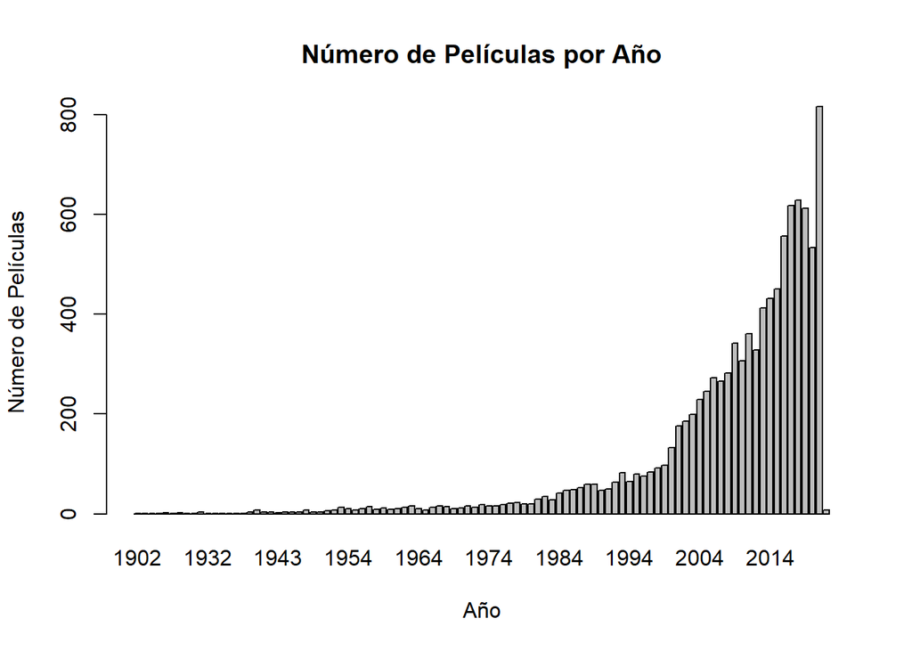

```r
# Crear gráfico de barras
barplot(peliculas_por_ano, main = "Número de Películas por Año", xlab = "Año", ylab = "Número de Películas")
```

En el año 2021 se hicieron más películas. con un total de 816. Se nota que hay un crecimiento exponencial ya que entre más pasa el tiempo se realizan más peliculas

### 4.6 ¿Cuál es el género principal de las 20 películas más recientes? ¿Cuál es el género principal que predomina en el conjunto de datos? Represéntelo usando un gráfico

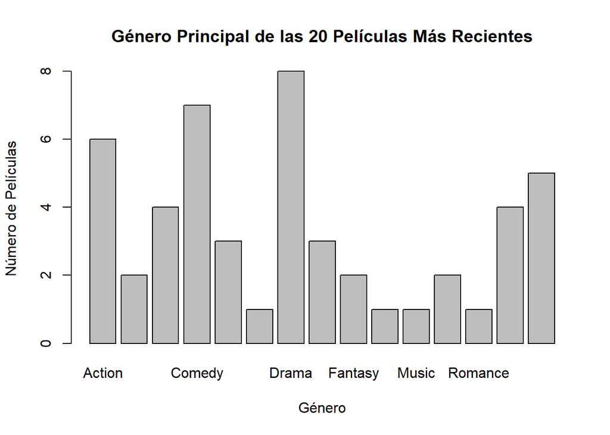

```r
# Suponiendo que releaseDate es una cadena en el formato "YYYY-MM-DD"
datos$releaseYear <- as.numeric(format(as.Date(datos$releaseDate), "%Y"))

# Ordenar las películas por fecha de lanzamiento de manera descendente
datos_ordenados <- datos[order(-datos$releaseYear), ]

# Seleccionar las 20 películas más recientes
top_20_recientes <- head(datos_ordenados, 20)

# Obtener el género principal de las 20 películas más recientes
genero_principal_top_20 <- table(unlist(strsplit(top_20_recientes$genres, "\\|")))

# Obtener el género principal que predomina en el conjunto de datos
genero_principal_total <- table(unlist(strsplit(datos$genres, "\\|")))

# Encontrar el género principal más común
genero_principal_mas_comun <- names(genero_principal_total[which.max(genero_principal_total)])

# Crear gráfico de barras para el género principal de las 20 películas más recientes
barplot(genero_principal_top_20, main = "Género Principal de las 20 Películas Más Recientes", xlab = "Género", ylab = "Número de Películas")
```

```r
# Imprimir el género principal de las 20 películas más recientes
cat("\nGénero Principal de las 20 Películas Más Recientes:\n")
```

```
##
## Género Principal de las 20 Películas Más Recientes:
```

```r
print(genero_principal_top_20)
```

```
##
##          Action       Adventure       Animation          Comedy           Crime
##               6               2               4               7               3
##     Documentary           Drama          Family         Fantasy          Horror
##               1               8               3               2               1
##           Music         Mystery         Romance Science Fiction        Thriller
##               1               2               1               4               5
```

```r
# Imprimir el género principal que predomina en el conjunto de datos
cat("\nGénero Principal que Predomina en el Conjunto de Datos:\n")
```

```
##
## Género Principal que Predomina en el Conjunto de Datos:
```

```r
print(genero_principal_mas_comun)
```

```
## [1] "Drama"
```

El género principal de las 20 películas es Drama seguido de Comedia y acción

### 4.7 ¿Las películas de qué genero principal obtuvieron mayores ganancias?

```r
# Seleccionar las primeras 10 filas con los campos 'title' y 'genre'
top_10_revenue <- head(datos[order(-datos$revenue), c("title", "genres")], 15)

# Contar la frecuencia de cada género
genre_counts <- top_10_revenue   %>%
  mutate(first_genre = str_extract(genres, "^[^|]+")) %>%
  count(first_genre) %>%
  arrange(desc(n))


print(genre_counts)
```

```
##       first_genre n
## 1          Action 7
## 2       Adventure 3
## 3 Science Fiction 2
## 4           Drama 1
## 5          Family 1
## 6         Fantasy 1
```

Interpretando la pregunta como el conteo de los géneros de las películas con mayores ingresos, las de acción son las lideran el conteo con un total de 7, seguidas de las de aventura con 3, ciencia ficción con 2 y tanto drama, familia y fantasía con 1.

```r
# Seleccionar las primeras 10 filas
top_10_revenue <- head(datos[order(-datos$revenue), c("title", "genres", "revenue")], 100)

# Seleccionar las películas con mayor "revenue" por género
top_by_genre <- top_10_revenue %>%
  group_by(first_genre = str_extract(genres, "^[^|]+")) %>%
  top_n(1, revenue) %>%
  ungroup()

# Contar la frecuencia de cada género
genre_counts <- top_by_genre %>%
  count(first_genre, top_title = title, revenue=revenue) %>%
  arrange(desc(revenue))

print(genre_counts)
```

```
## # A tibble: 10 × 4
##    first_genre     top_title                                       revenue     n
##    <chr>           <chr>                                             <dbl> <int>
##  1 Action          Avatar                                       2847246203     1
##  2 Adventure       Avengers: Endgame                            2797800564     1
##  3 Drama           Titanic                                      2187463944     1
##  4 Science Fiction The Avengers                                 1518815515     1
##  5 Family          Frozen II                                    1450026933     1
##  6 Fantasy         Harry Potter and the Deathly Hallows: Part 2 1341511219     1
##  7 Animation       Frozen                                       1274219009     1
##  8 Crime           Joker                                        1074251311     1
##  9 Music           Bohemian Rhapsody                             894027543     1
## 10 War             Wolf Warrior 2                                870322670     1
```

Interpretando la pregunta como obtener de cada género la película con mayor ingreso, esta tabla muestra los resultados. Es notable que entre los primeros puestos no existe una gran diferencia, por lo que es posible decir que al menos los 8 primeros puestos pertenecen también a los puestos del top ingresos globales.

### 4.8 ¿La cantidad de actores influye en los ingresos de las películas?¿se han hecho películas con más actores en los últimos años?

```r
# Obtener el top 100 de peliculas con más cantidad de actores
actorAmount <- head(datos[order(-datos$actorsAmount), c("title", "actorsAmount", "revenue")], 100)

# Filtrar los datos para quitar las observaciones con revenue vacía o igual a 0
actorAmount_filtrados <- actorAmount %>%
  filter(!is.na(revenue) & revenue != 0) %>%
  slice(3:n())

# Imprimir los datos filtrados
print(actorAmount_filtrados)
```

```
##                                                title actorsAmount    revenue
## 1                    Around the World in Eighty Days          313   42000000
## 2                                          Enchanted          248  340487652
## 3                        Mamma Mia! Here We Go Again          227  395044706
## 4                                       Rock of Ages          220   59418613
## 5                       Mr. Smith Goes to Washington          213    9600000
## 6                                  Les Mis\xe9rables          207  441809770
## 7                                     Gangster Squad          198  105200903
## 8                                       Jason Bourne          196  415484914
## 9                       Star Wars: The Force Awakens          188 2068223624
## 10                                   Angels & Demons          187  485930816
## 11                                          Invictus          183  122426792
## 12                                         Star Trek          182  385680446
## 13                     You Don't Mess with the Zohan          181  204313400
## 14                      Rogue One: A Star Wars Story          181 1056057273
```

[output cut: 43 more lines]

```r
# Calcular la correlación entre cantidad de actores y los ingresos
correlation <- cor(actorAmount_filtrados$actorsAmount, actorAmount_filtrados$revenue)
correlation
```

```
## [1] -0.03148028
```

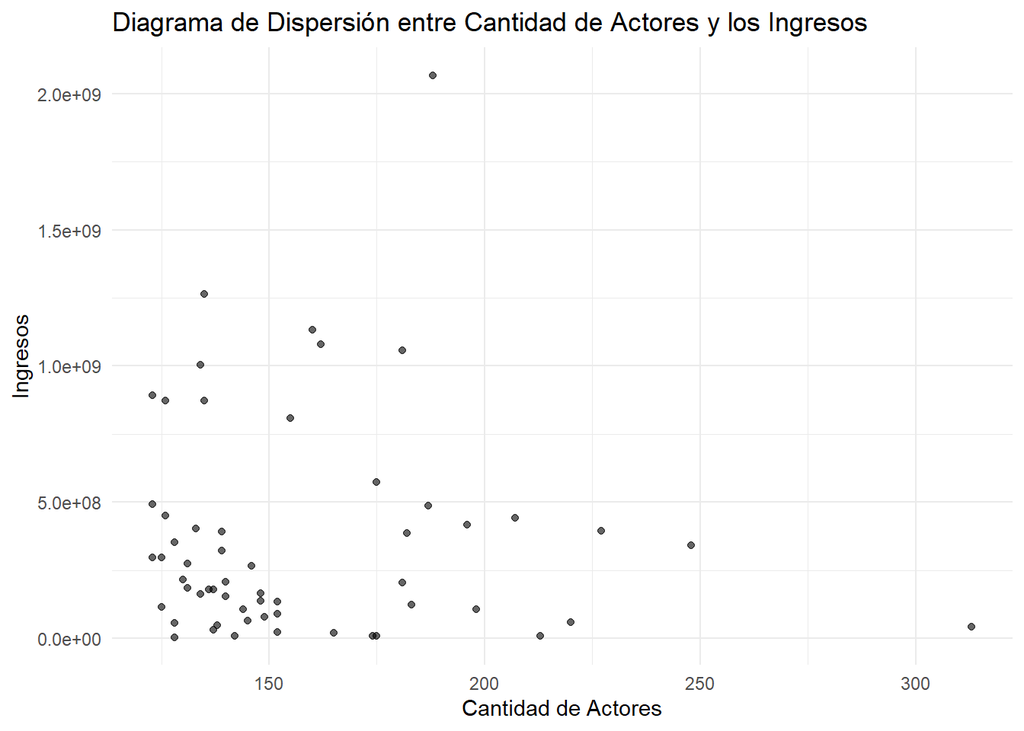

```r
# Diagrama de dispersión entre cantidad de actores y los ingresos
ggplot(actorAmount_filtrados, aes(x = actorsAmount, y = revenue)) +
  geom_point(alpha = 0.6) +
  labs(title = "Diagrama de Dispersión entre Cantidad de Actores y los Ingresos", label = paste("Correlación:", round(correlation, 2)),
       x = "Cantidad de Actores",
       y = "Ingresos") +
  theme_minimal()
```

Como tal, según nuestro diagrama de dispersión y el índice de correlación entre la cantidad de actores y los ingresos de las películas, no existe como tal una relación entre estas variables, por lo que la cantidad de actores no influye en los ingresos de las películas.

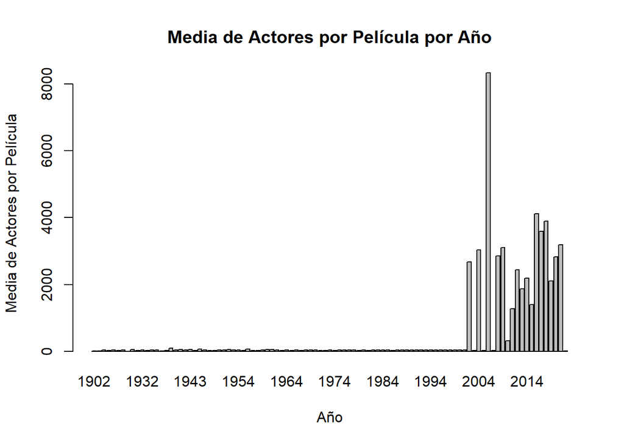

```r
datos <- read.csv("movies.csv")

# Suponiendo que releaseDate es una cadena en el formato "YYYY-MM-DD"
datos$releaseYear <- as.numeric(format(as.Date(datos$releaseDate), "%Y"))

# Calcular la media de actores por película para cada año
media_actores_por_año <- aggregate(actorsAmount ~ releaseYear, data = datos, FUN = mean)

# Crear una gráfica de barras
barplot(media_actores_por_año$actorsAmount, names.arg = media_actores_por_año$releaseYear,
        main = "Media de Actores por Película por Año", xlab = "Año", ylab = "Media de Actores por Película")
```

Según el gráfico, se observa que a partir de aproximadamente el año 2000 se han hecho películas con más actores que antes, sin embargo, no es un crecimiento constante, ya que a partir de ahí han habido años con más o menos cantidad sin mostrar ningún patrón aparente.

### 4.9 ¿Es posible que la cantidad de hombres y mujeres en el reparto influya en la popularidad y los ingresos de las películas?

```r
datos <- read.csv("movies.csv")

# Cantidad de actores
datos$castMenTotal <- as.integer(datos$castMenAmount)
# Cantidad de actrices
datos$castWomenTotal <- as.integer(datos$castWomenAmount)
# Omitir los datos NA
datos <- na.omit(datos[, c("popularity", "revenue", "castMenTotal", "castWomenTotal")])

# Calcular las correlaciones
correlationPopularityWomen <- cor(datos$popularity, datos$castWomenTotal)
correlationPopularityMen <- cor(datos$popularity, datos$castMenTotal)
correlationRevenueWomen <- cor(datos$revenue, datos$castWomenTotal)
correlationRevenueMen <- cor(datos$revenue, datos$castMenTotal)

cat("\nCorrelacion entre popularidad y la cantidad de mujeres en el reparto:")
```

```
##
## Correlacion entre popularidad y la cantidad de mujeres en el reparto:
```

```r
print(correlationPopularityWomen)
```

```
## [1] 0.0389395
```

```r
cat("\nCorrelacion entre los ingresos  y la cantidad de mujeres en el reparto:")
```

```
##
## Correlacion entre los ingresos  y la cantidad de mujeres en el reparto:
```

```r
print(correlationPopularityMen)
```

```
## [1] 0.002778599
```

```r
cat("\nCorrelacion entre popularidad y la cantidad de hombres en el reparto:")
```

```
##
## Correlacion entre popularidad y la cantidad de hombres en el reparto:
```

```r
print(correlationRevenueWomen)
```

```
## [1] 0.2900703
```

```r
cat("\nCorrelacion entre los ingresos y la cantidad de hombres en el reparto:")
```

```
##
## Correlacion entre los ingresos y la cantidad de hombres en el reparto:
```

```r
print(correlationRevenueMen)
```

```
## [1] -0.0601431
```

Según los valores de las correlaciones, ninguna de es lo suficientemente alta como para indicar algún tipo de relación o influencia entre la cantidad de los actores y actrices con la popularidad e ingresos de las películas.

### 4.10 ¿Quiénes son los directores que hicieron las 20 películas mejor calificadas?

```r
datos <- read.csv("movies.csv")
# Seleccionar las primeras 20 filas segun la calificacion promedio de la pelicula
top_10_rating <- head(datos[order(-datos$voteAvg), c("title", "voteAvg", "director")], 20)

# Filtrar las películas para quitar aquellas que no tienen registro de director
top_10_rating <- top_10_rating %>%
  filter(!is.na(director) & director != "")

print(top_10_rating)
```

```
##                                                     title voteAvg
## 1                                Hot Naked Sex & the City    10.0
## 2                                                Holidays    10.0
## 3          Steven Universe: The Movie: Behind the Curtain    10.0
## 4        Spirit of Vengeance: The Making of 'Ghost Rider'    10.0
## 5   How Ponyo was Born ~Hayao Miyazaki's Thought Process~    10.0
## 6                                  Christmas at the Ranch    10.0
## 7                                Los Vengadores Chiflados    10.0
## 8         The Spectacular Spider-Man Attack of the Lizard     9.6
## 9                                           Ebola Zombies     9.5
## 10                                    Aunt's Temptation 3     9.5
## 11                                 Live: The Last Concert     9.4
## 12 Demon Slayer: Kimetsu no Yaiba the Hashira Meeting Arc     9.3
## 13          Demon Slayer: Kimetsu no Yaiba Sibling's Bond     9.3
## 14                   Franco Escamilla: Por La An\xe9cdota     9.2
```

[output cut: 17 more lines]

En la tabla generada se muestran los directores de las 20 películas mejor calificadas.

### 4.11 ¿Cómo se correlacionan los presupuestos con los ingresos? ¿Los altos presupuestos significan altos ingresos? Haga los gráficos que necesite, histograma, diagrama de dispersión

```r
# Calcular la correlación entre presupuestos y ingresos
correlation <- cor(datos$budget, datos$revenue)
correlation
```

```
## [1] 0.757454
```

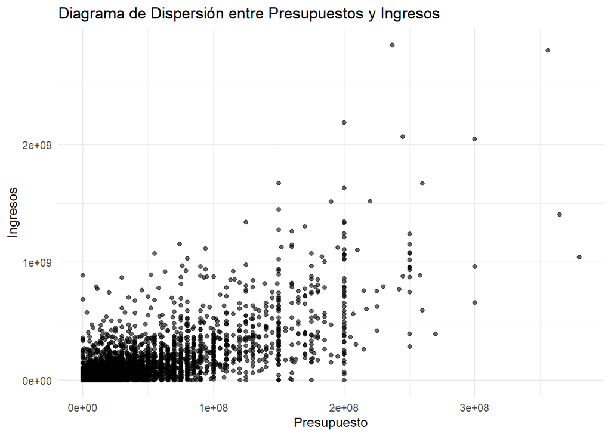

```r
# Diagrama de dispersión entre presupuestos y ingresos
ggplot(datos, aes(x = budget, y = revenue)) +
  geom_point(alpha = 0.6) +
  labs(title = "Diagrama de Dispersión entre Presupuestos y Ingresos", label = paste("Correlación:", round(correlation, 2)),
       x = "Presupuesto",
       y = "Ingresos") +
  theme_minimal()
```

Es diagrama de dispersión generado muestra que efectivamente, existe una relación entre la cantidad de presupuesto y los ingresos. A mayor presupuesto es esperable una mayor recaudación y viceversa. Esto se ve corroborado por el índice de correlación generado, pues este siendo 0.76 se mantiene dentro de un rango donde es aceptable indicar correlación.

### 4.12 ¿Se asocian ciertos meses de lanzamiento con mejores ingresos?

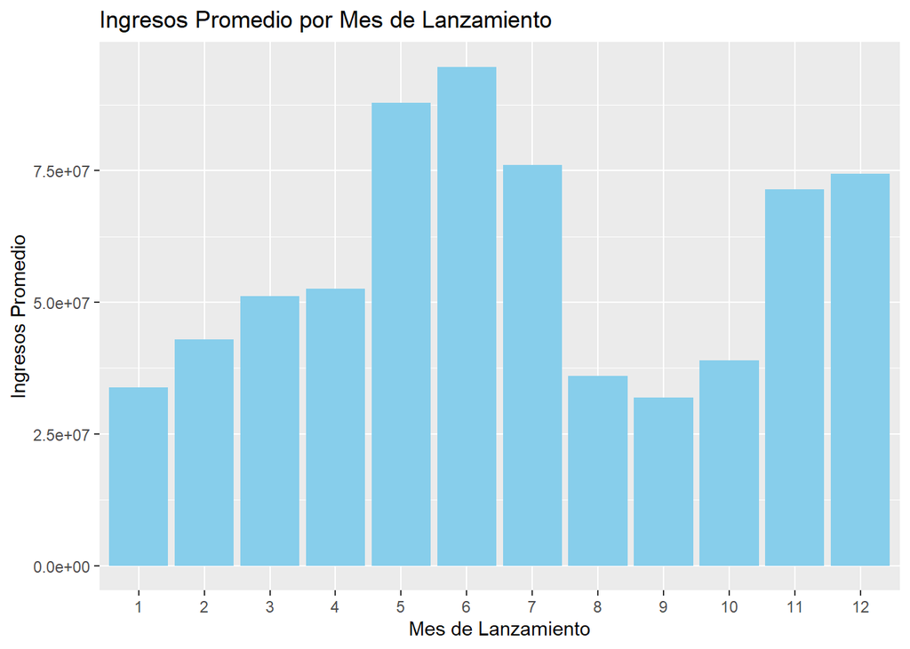

```r
# Convertir la fecha de lanzamiento a formato de fecha y extraer el mes
datos$releaseMonth <- as.numeric(format(as.Date(datos$releaseDate), "%m"))

# Calcular el promedio de ingresos por mes
ingresos_promedio_por_mes <- aggregate(revenue ~ releaseMonth, data = datos, FUN = mean)

# Crear gráfico de barras
ggplot(ingresos_promedio_por_mes, aes(x = factor(releaseMonth), y = revenue)) +
  geom_bar(stat = "identity", fill = "skyblue") +
  labs(title = "Ingresos Promedio por Mes de Lanzamiento",
       x = "Mes de Lanzamiento",
       y = "Ingresos Promedio")
```

Los meses de mayo, junio y julio son los meses que han tenido la mayor cantidad promedio de ingresos, estos seguidos de diciembre y noviembre. Esto puede indicar que existe una relación entre la época de estreno y la cantidad de recaudación, pues precisamente todos estos meses pueden considerarse como vacacionales.

Los meses con menor promedio de ingresos son septiembre, enero, agosto y octubre.

### 4.13 ¿En qué meses se han visto los lanzamientos con mejores ingresos? ¿cuantas películas, en promedio, se han lanzado por mes?

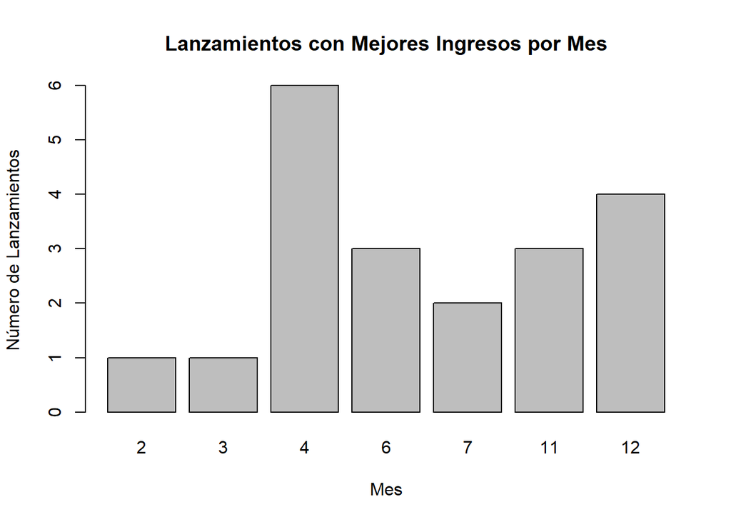

```r
# Convertir la fecha de lanzamiento a formato de fecha y extraer el mes
datos$releaseMonth <- as.numeric(format(as.Date(datos$releaseDate), "%m"))

# Seleccionar las primeras 20 filas de las peliculas con mejores ingresos
top_20_revenue <- head(datos[order(-datos$revenue), c("title", "revenue", "releaseMonth")], 20)

# Contar la frecuencia de lanzamientos por mes
conteo_por_mes <- table(top_20_revenue$releaseMonth)

# Crear gráfico de barras
barplot(conteo_por_mes, main = "Lanzamientos con Mejores Ingresos por Mes", xlab = "Mes", ylab = "Número de Lanzamientos")
```

Los lanzamientos con mejores ingresos, tomando en cuenta que se toman los primeros 20 puestos, se han visto principalmente en el mes de abril, seguido de diciembre, junio y noviembre. Esta grafica también nos muestra que ningúna película dentro del top de ingresos se ha estrenado en enero, mayo, agosto, septiembre ni octubre.

```r
# Suponiendo que releaseDate es una cadena en el formato "YYYY-MM-DD"
datos$releaseYear <- as.numeric(format(as.Date(datos$releaseDate), "%Y"))

# Suponiendo que releaseDate es una cadena en el formato "YYYY-MM-DD"
datos$releaseMonth <- as.numeric(format(as.Date(datos$releaseDate), "%m"))

# Crear tabla con el número de películas por mes
peliculas_por_mes <- table(datos$releaseMonth)

# Calcular el número total de años en el conjunto de datos
num_anos <- length(unique(datos$releaseYear))

# Calcular el promedio de películas por mes
promedio_peliculas_por_mes <- peliculas_por_mes / num_anos

# Imprimir el promedio de películas por mes
cat("Promedio de películas por mes:\n")
```

```
## Promedio de películas por mes:
```

```r
print(promedio_peliculas_por_mes)
```

```
##
##         1         2         3         4         5         6         7         8
##  6.585859  7.131313  8.232323  7.030303  7.050505  8.272727  8.202020  9.222222
##         9        10        11        12
## 10.898990 10.787879  8.151515  9.444444
```

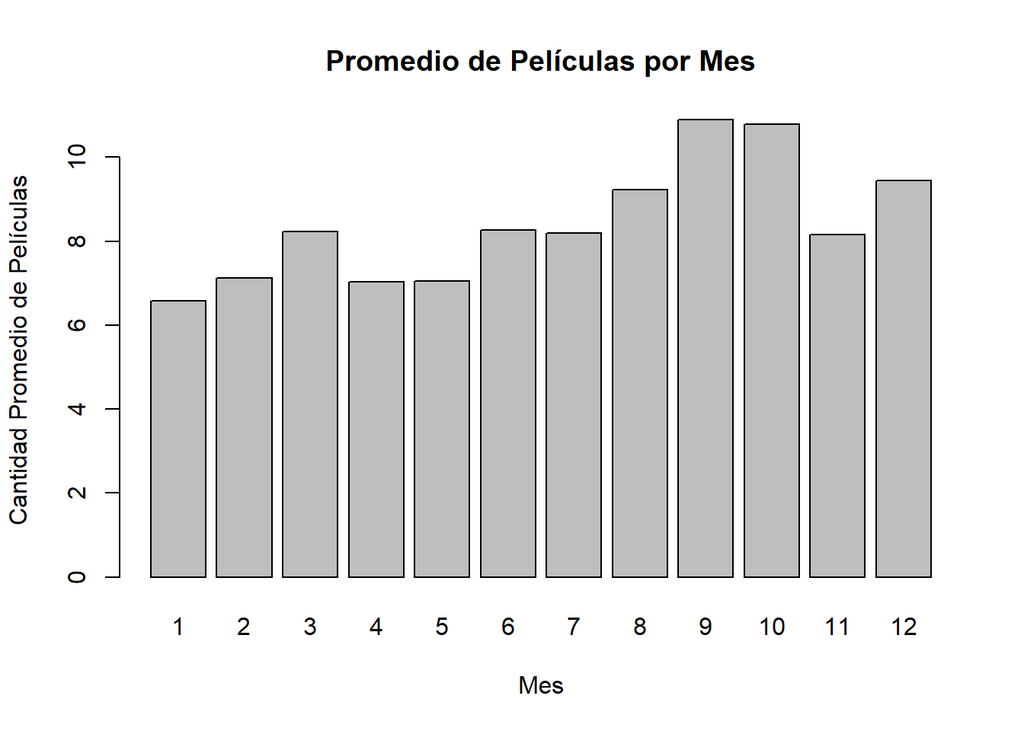

```r
# Crear gráfico de barras
barplot(promedio_peliculas_por_mes, main = "Promedio de Películas por Mes", xlab = "Mes", ylab = "Cantidad Promedio de Películas")
```

Esta grafica muestra el promedio de películas estrenadas durante los 12 meses en todos los años. Los meses con una mayor cantidad de películas estrenadas son septiembre y octubre con un promedio de 10 películas.

### 4.14 ¿Cómo se correlacionan las calificaciones con el éxito comercial?

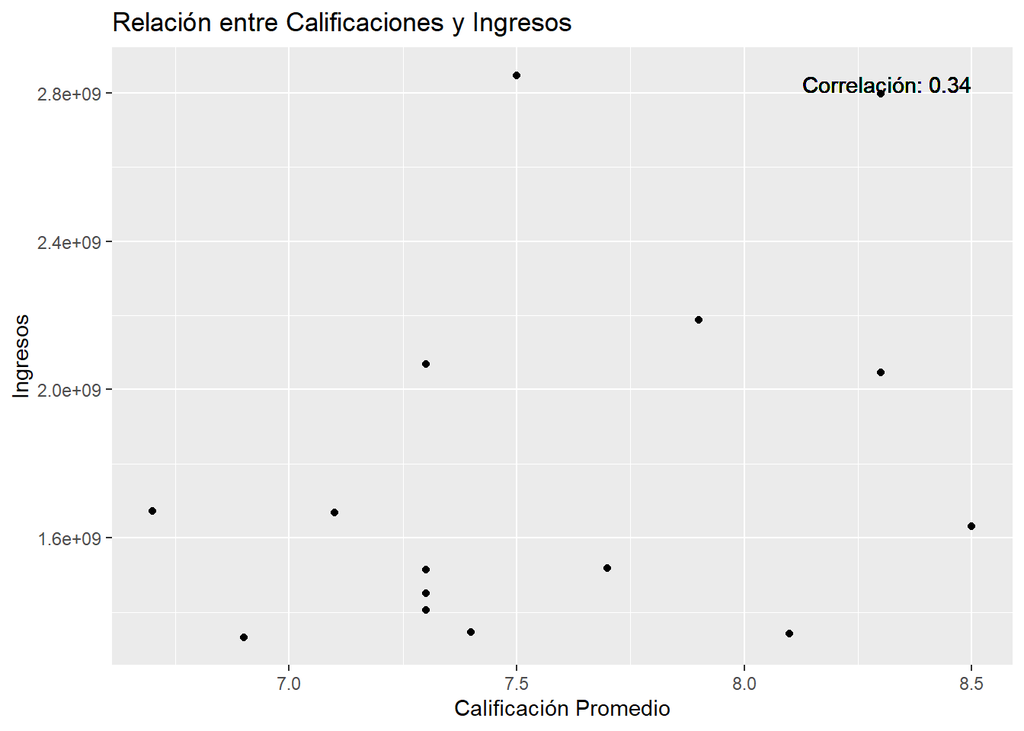

```r
# Seleccionar las primeras 15 filas con los campos 'title', 'revenue', 'voteAvg'
top_10_revenue <- head(datos[order(-datos$revenue), c("title", "revenue", "voteAvg")], 15)

# Calcular la correlación entre las calificaciones y los ingresos
correlation <- cor(top_10_revenue$voteAvg, top_10_revenue$revenue)

# Graficar la relación entre calificaciones y ingresos con la correlación
ggplot(top_10_revenue, aes(x = voteAvg, y = revenue)) +
  geom_point() +
  geom_text(aes(label = paste("Correlación:", round(correlation, 2)), x = max(voteAvg), y = max(revenue)), vjust = 1, hjust = 1) +
  labs(title = "Relación entre Calificaciones y Ingresos",
       x = "Calificación Promedio",
       y = "Ingresos")
```

No existe una relación entre las calificaciones y el éxito comercial, esto se corrobora en primer lugar con el índice de correlación que es demasiado bajo, y también con la gráfica generada, pues no hay ningún patrón observable, más allá de decir que las películas con mejor recaudación oscilan entre 6.5 y 8.5 de calificación.

### 4.15 ¿A qué género principal pertenecen las películas más largas?

```r
# Seleccionar las primeras 20 filas con las peliculas mas largas
top_10_runtime <- head(datos[order(-datos$runtime), c("title", "genres")], 20)

# Contar la frecuencia de cada género
genre_counts <- top_10_runtime %>%
  mutate(first_genre = str_extract(genres, "^[^|]+")) %>%
  count(first_genre) %>%
  arrange(desc(n))


print(genre_counts)
```

```
##   first_genre n
## 1       Drama 7
## 2      Action 5
## 3 Documentary 4
## 4      Comedy 1
## 5       Crime 1
## 6       Music 1
## 7         War 1
```

Entendiendo la pregunta como el conteo del genero principal al que pertenecen las películas con mayor duración, dentro de los primeros 20 puestos tenemos que existe un total de 7 películas de drama, 5 películas de acción, 4 películas documentales y una película de comedia, crimen, musical y guerra. Concluyendo entonces que el género de drama es el que predomina dentro de las 20 películas más largas.

### 5.1 Cómo se distribuye la duración de las peliculas

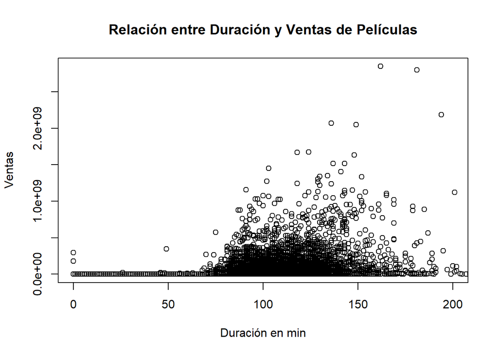

```r
# Definir límites deseados para el eje x
limites_x <- c(0, 200)

plot(datos$runtime, datos$revenue, main = "Relación entre Duración y Ventas de Películas", xlab = "Duración en min", ylab = "Ventas", xlim = limites_x)
```

El gráfico de dispersión generado ofrece una perspectiva reveladora sobre la relación entre la duración de las películas y sus ventas en el conjunto de datos. Al observar el gráfico, podemos identificar patrones o tendencias que podrían indicar cómo el rango de 100 a 150 de duración están asociados con niveles bastante altos en las ventas en la industria cinematográfica. La dispersión de puntos a lo largo de los ejes x e y proporciona una representación visual de la variabilidad en las duraciones de las películas y las ventas asociadas. Los datos revelan que una duración óptima de las películas para tener un mayor margen de ganacias se encuentra entre los 100 a los 150 minutos y como se evidencia la mayoría de las películas se encuentran en este a pesar de no haber tenido ganancias.

### 5.2 Existe una relación entre la popularidad y las votaciones

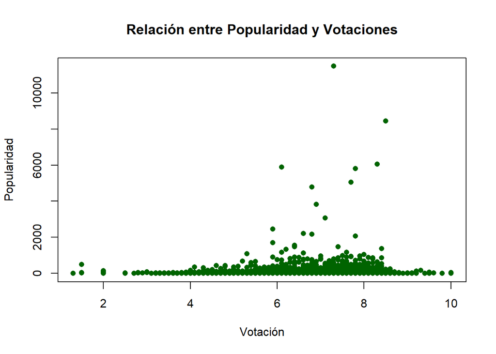

```r
# Crear diagrama de dispersión
plot(datos$voteAvg,datos$popularity, main = "Relación entre Popularidad y Votaciones", xlab = "Votación", ylab = "Popularidad", pch = 16, col = "darkgreen")
```

```r
# Calcular el coeficiente de correlación
correlation <- cor(datos$popularity, datos$voteAvg)

# Imprimir el coeficiente de correlación
print(paste("Coeficiente de correlación:", correlation, " gracias a esto podemos concluir que hay una relación muy débil entre la popularidad y las votaciones"))
```

```
## [1] "Coeficiente de correlación: 0.066436273912612  gracias a esto podemos concluir que hay una relación muy débil entre la popularidad y las votaciones"
```

El gráfico de dispersión generado ofrece una perspectiva reveladora sobre la relación entre la popularidad de las películas y sus punteos en las votacines en el conjunto de datos. Al observar el gráfico, podemos identificar patrones o tendencias que podrían indicar cómo el rango de 5 a 8 de votación están asociados con niveles bastante altos en la popularidad en la industria cinematográfica.Los datos revelan que si la película es popular y posee un gran público el promedio de los votos es normalmente entre 5 a 8 puntos ya que al tener un público variado este poseera distintas críticas y no permitirá que se tengan notas tan altas como en los puntos donde la popularidad es muy baja y sesga los datos a muy altos o muy bajos debido a la cantidad de público que fue a visualizarla.